# rsotosan_PEC4.Rmd

Ramon Soto

2022-05-22

# 1 Lectura y preparación de los datos

Tras leer el dataset vemos que hay diez columnas de las cuales 4 son booleanas, 5 numéricas y una única se ha leído como cualitativa. La trasnformaremos a continuación

```r
setwd("D:/uoc/estadistica avanzada/PEC4/" );

gpa <-
  read.table("gpa.csv",
             header=TRUE, stringsAsFactors=TRUE, sep=",", na.strings="NA", dec=".",
             strip.white=TRUE)
dim(gpa)
```

```
## [1] 4137   10
```

```r
str(gpa)
```

```
## 'data.frame':    4137 obs. of  10 variables:
##  $ sat    : int  920 1170 810 940 1180 980 880 980 1240 1230 ...
##  $ tothrs : Factor w/ 125 levels "100h","101h",..: 67 46 42 64 46 16 103 79 46 45 ...
##  $ hsize  : num  0.1 9.4 1.19 5.71 2.14 ...
##  $ hsrank : int  4 191 42 252 86 41 161 101 161 3 ...
##  $ hsperc : num  40 20.3 35.3 44.1 40.2 ...
##  $ colgpa : num  2.04 4 1.78 2.42 2.61 ...
##  $ athlete: logi  TRUE FALSE TRUE FALSE FALSE FALSE ...
##  $ female : logi  TRUE FALSE FALSE FALSE FALSE TRUE ...
##  $ white  : logi  FALSE TRUE TRUE TRUE TRUE TRUE ...
##  $ black  : logi  FALSE FALSE FALSE FALSE FALSE FALSE ...
```

```r
head(gpa)
```

```
##    sat tothrs hsize hsrank   hsperc colgpa athlete female white black
## 1  920    43h  0.10      4 40.00000   2.04    TRUE   TRUE FALSE FALSE
## 2 1170    18h  9.40    191 20.31915   4.00   FALSE  FALSE  TRUE FALSE
## 3  810    14h  1.19     42 35.29412   1.78    TRUE  FALSE  TRUE FALSE
## 4  940    40h  5.71    252 44.13310   2.42   FALSE  FALSE  TRUE FALSE
## 5 1180    18h  2.14     86 40.18692   2.61   FALSE  FALSE  TRUE FALSE
## 6  980   114h  2.68     41 15.29851   3.03   FALSE   TRUE  TRUE FALSE
```

## 1.1 Preparación de los datos

La variable othrs, debido a la hache que contienen todos los valores, no se ha cargado como numérica.  
Al pasar la función extract_numeric se obtiene la parte numérica.

```r
gpa$tothrs<-extract_numeric(gpa$tothrs)
```

```
## extract_numeric() is deprecated: please use readr::parse_number() instead
```

```r
class(gpa$tothrs)
```

```
## [1] "numeric"
```

## 1.2 Valores ausentes

Al hacer un resumen estadístico de cada atributo vemos que colgpa es el único que presenta valores ausentes.

Su porcentaje, calculado abajo, es ínfimo. Procedemos entonces a eliminar esas filas.

```r
summary(gpa)
```

```
##       sat           tothrs           hsize          hsrank
##  Min.   : 470   Min.   :  6.00   Min.   :0.03   Min.   :  1.00
##  1st Qu.: 940   1st Qu.: 17.00   1st Qu.:1.65   1st Qu.: 11.00
##  Median :1030   Median : 47.00   Median :2.51   Median : 30.00
##  Mean   :1030   Mean   : 52.83   Mean   :2.80   Mean   : 52.83
##  3rd Qu.:1120   3rd Qu.: 80.00   3rd Qu.:3.68   3rd Qu.: 70.00
##  Max.   :1540   Max.   :137.00   Max.   :9.40   Max.   :634.00
##
##      hsperc            colgpa       athlete          female
##  Min.   : 0.1667   Min.   :0.000   Mode :logical   Mode :logical
##  1st Qu.: 6.4328   1st Qu.:2.210   FALSE:3943      FALSE:2277
##  Median :14.5833   Median :2.660   TRUE :194       TRUE :1860
##  Mean   :19.2371   Mean   :2.655
##  3rd Qu.:27.7108   3rd Qu.:3.120
##  Max.   :92.0000   Max.   :4.000
##                    NA's   :41
##    white           black
##  Mode :logical   Mode :logical
##  FALSE:308       FALSE:3908
##  TRUE :3829      TRUE :229
##
##
##
##
```

```r
sum(is.na(gpa))/dim(gpa)[1]
```

```
## [1] 0.009910563
```

```r
NA.reg <- which(is.na(gpa$colgpa))
gpaclean <- gpa[-NA.reg,]
dim(gpaclean)
```

```
## [1] 4096   10
```

## 1.3 Equivalencia de la nota en letras

Creamos la nueva variable categórica que discretiza colgpa

```r
gpaclean$gpaletter <- NULL
gpaclean$gpaletter[ gpaclean$colgpa >= 3.5 & gpaclean$colgpa <= 4 ] <- "A"
gpaclean$gpaletter[ gpaclean$colgpa >= 2.5 & gpaclean$colgpa < 3.5 ] <- "B"
gpaclean$gpaletter[ gpaclean$colgpa >= 1.5 & gpaclean$colgpa < 2.5] <- "C"
gpaclean$gpaletter[ gpaclean$colgpa >= 0 & gpaclean$colgpa < 1.5] <- "D"
```

# 2 Estadística descriptiva y visualización

## 2.1 Análisis descriptivo

Volvemos a mostrar un resumen del dataset tras las modificaciones del apartado anterior. El número de observaciones se ha reducido a 4096

y ahora hay 11 atributos.

A continuación elaboramos un resumen estadístico para cada atributo numérico.

```r
dim(gpaclean)
```

```
## [1] 4096   11
```

```r
summary(gpaclean)
```

```
##       sat           tothrs           hsize           hsrank
##  Min.   : 470   Min.   :  6.00   Min.   :0.030   Min.   :  1.00
##  1st Qu.: 940   1st Qu.: 17.00   1st Qu.:1.647   1st Qu.: 11.00
##  Median :1030   Median : 47.00   Median :2.510   Median : 30.00
##  Mean   :1031   Mean   : 52.78   Mean   :2.795   Mean   : 52.74
##  3rd Qu.:1120   3rd Qu.: 80.00   3rd Qu.:3.660   3rd Qu.: 70.00
##  Max.   :1540   Max.   :137.00   Max.   :9.400   Max.   :634.00
##      hsperc            colgpa       athlete          female
##  Min.   : 0.1667   Min.   :0.000   Mode :logical   Mode :logical
##  1st Qu.: 6.4252   1st Qu.:2.210   FALSE:3905      FALSE:2253
##  Median :14.5833   Median :2.660   TRUE :191       TRUE :1843
##  Mean   :19.2227   Mean   :2.655
##  3rd Qu.:27.6755   3rd Qu.:3.120
##  Max.   :92.0000   Max.   :4.000
##    white           black          gpaletter
##  Mode :logical   Mode :logical   Length:4096
##  FALSE:304       FALSE:3871      Class :character
##  TRUE :3792      TRUE :225       Mode  :character
##
##
##
```

```r
estudio<- select(gpaclean, sat,tothrs,hsize,hsrank,hsperc,colgpa)
media_aritmetica<-apply(estudio, 2, mean, na.rm = TRUE)
mediana<-apply(estudio, 2, median, na.rm = TRUE)
desviacion_estandar<-apply(estudio, 2, sd, na.rm = TRUE)
desviacion_abs_med<-apply(estudio, 2, mad, na.rm = TRUE)
rango_interc<-apply(estudio, 2, IQR, na.rm = TRUE)
resumen<-rbind(media_aritmetica,mediana,desviacion_estandar,desviacion_abs_med,rango_interc)
resumen
```

```
##                           sat   tothrs    hsize   hsrank   hsperc    colgpa
## media_aritmetica    1030.9058 52.78052 2.794783 52.73926 19.22266 2.6545459
## mediana             1030.0000 47.00000 2.510000 30.00000 14.58333 2.6600001
## desviacion_estandar  139.3354 35.32411 1.731629 64.61821 16.56035 0.6601642
## desviacion_abs_med   133.4340 45.96060 1.423296 35.58240 14.08260 0.6819957
## rango_interc         180.0000 63.00000 2.012500 59.00000 21.25030 0.9099999
```

## 2.2 Visualización

A continuación vemos que la distribución de SAT tienen un un rango intercuartil bastante estrecho. En la tabla de arriba hemos visto que la mediana y la media prácticamente coinciden. Existen bastantes puntos que superan los extemos máximo y mínimo.

Haciendo disgregación por la variable female se aprecia que la mediana es sensiblemente inferior para TRUE si bien se mantienen por encima de 1000 puntos y en este grupo la distribución presenta menos casos fuera de los extremos. Si consideramos la variable athlete la distribución presenta una mediana bastante más a la izquierda. Podemos considerar que Athlete es un factor que afecta a en general al valor de sat.

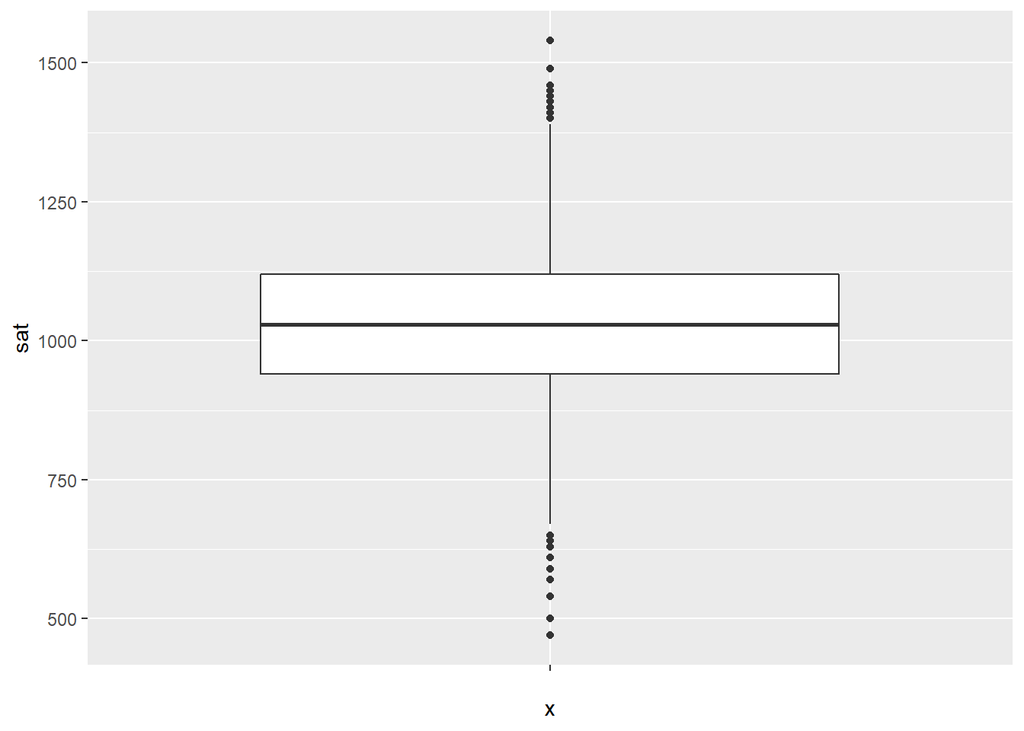

```r
ggplot(gpaclean, aes(x="", y=sat)) +
  geom_boxplot()
```

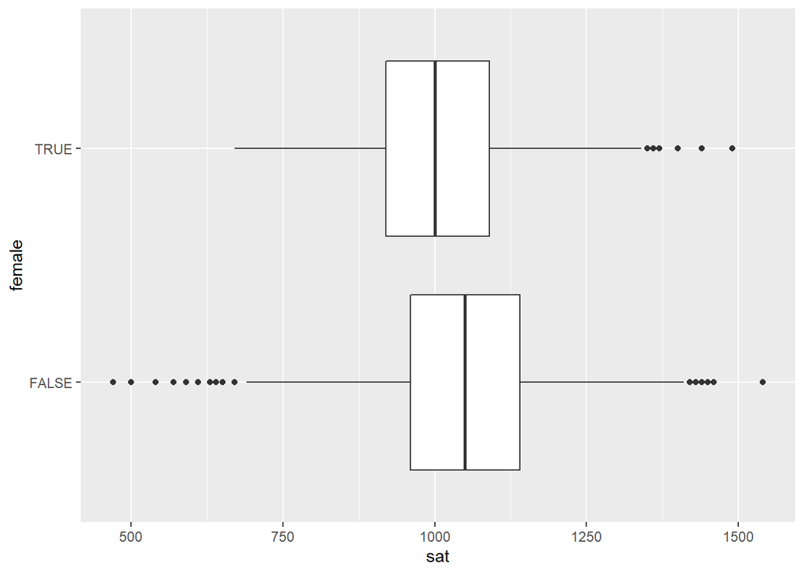

```r
ggplot(gpaclean, aes(x=sat, y=female)) +
  geom_boxplot()
```

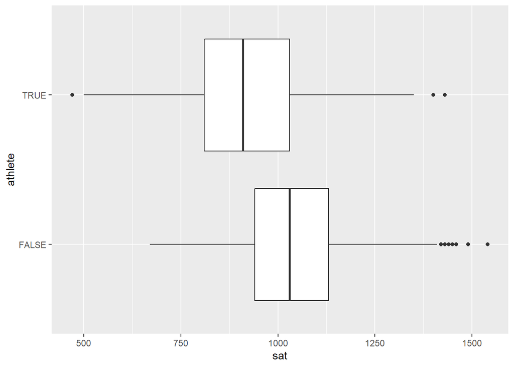

```r
ggplot(gpaclean, aes(x=sat, y=athlete)) +
  geom_boxplot()
```

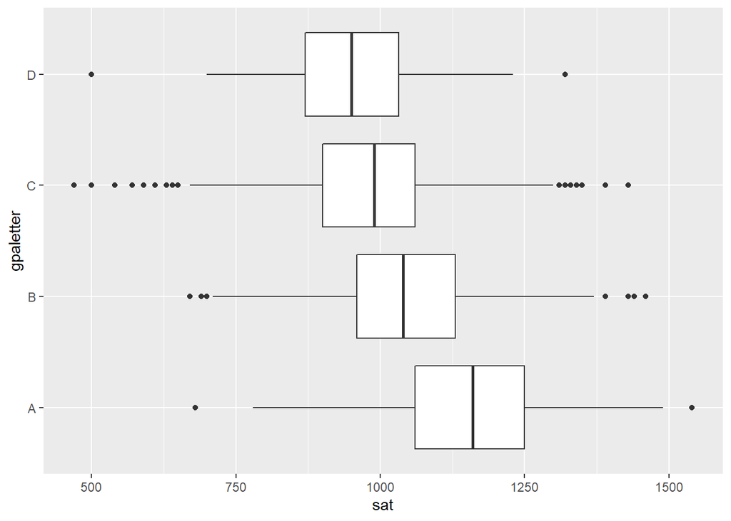

```r
ggplot(gpaclean, aes(x=sat, y=gpaletter)) +
  geom_boxplot()
```

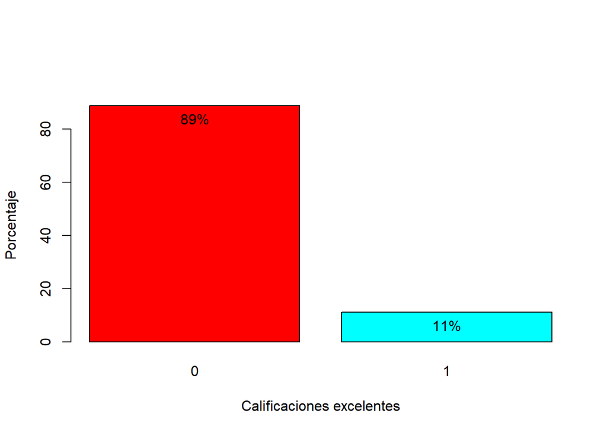

```r
gpaclean$excelente<-1*(gpaclean$gpaletter=="A")

Barplot(as.factor(gpaclean$excelente), style="divided",
        legend.pos="above", xlab="Calificaciones excelentes", ylab="Porcentaje", scale="percent",
        label.bars=TRUE, col=rainbow(2))
```

# 3 Estadística inferencial

## 3.1 Intervalo de confianza de la media poblacional de la variable sat

El intervalo de confianza para un valor de NC indica que la media de la población se encuentra en dicho intervalo con una confianza del NC*100%

```r
IC <- function( x, NC=0.9 ){
  alfa<-1-NC
  n<-length(x)
  desv<-sd(x)
  media<-mean(x)

  #Z contiene el valor para el que se cumple que P(X>z)=alfa/2
  z<-qnorm (alfa/2,lower.tail=FALSE)

  #Se devuelven los dos valores del intervalo

  return(c(media-(z*desv/sqrt(n)),media+(z*desv/sqrt(n))))

}

IC(gpaclean$sat,0.95)
```

```
## [1] 1026.639 1035.173
```

```r
# Cotejamos el resultado con t.test
t.test(gpaclean$sat)
```

```
##
##  One Sample t-test
##
## data:  gpaclean$sat
## t = 473.52, df = 4095, p-value < 2.2e-16
## alternative hypothesis: true mean is not equal to 0
## 95 percent confidence interval:
##  1026.637 1035.174
## sample estimates:
## mean of x
##  1030.906
```

A continuación calculamos los intervalos de confianza al 95% de la media poblacional de la variable sat en función de si los estudiantes son hombres o mujeres. El rango es de unas 12 unidades y existe una diferencia de unos 43 puntos ente ambos tal como se ve en la media calculada y en los diagramas de caja anteriores

```r
sat_hombres<-filter(gpaclean,female==FALSE)%>%select(sat)

sat_mujeres<-filter(gpaclean,female==TRUE)%>%select(sat)

IC(sat_hombres$sat,0.95)
```

```
## [1] 1044.257 1056.240
```

```r
IC(sat_mujeres$sat,0.95)
```

```
## [1] 1001.413 1013.107
```

## 3.2 Contraste de hipótesis para la diferencia de medias de colgpa

¿La nota media semestral para las estudiantes mujeres es distinta que la de los estudiantes hombres?

Planteamos la hipótesis nula y la hipótesis alternativa:

H0 mu1=mu2

H1 mu1!=mu2

Aquí podemos aplicar un contraste de hipótesis de dos muestras independientes (estudiantes mujeres y estudiantes hombres) sobre la media.

se trata de un contraste bilateral

Como no tenemos información la varianza es desconocida.

Para ver si las varianzas son iguales o no Hacemos un F-Test usamos la función var.test,

que hace el siguiente contraste de hipótesis bilateral con las varianzas de cada muestra:

H0 var1=var2

H1 var1!=var2

```r
colgpa_hombres<-filter(gpaclean,female==FALSE)%>%select(colgpa)

colgpa_mujeres<-filter(gpaclean,female==TRUE)%>%select(colgpa)


var.test(colgpa_mujeres$colgpa, colgpa_hombres$colgpa)
```

```
##
##  F test to compare two variances
##
## data:  colgpa_mujeres$colgpa and colgpa_hombres$colgpa
## F = 0.82788, num df = 1842, denom df = 2252, p-value = 2.305e-05
## alternative hypothesis: true ratio of variances is not equal to 1
## 95 percent confidence interval:
##  0.7589643 0.9033950
## sample estimates:
## ratio of variances
##          0.8278771
```

El p-valor es inferior a 0.05 luego descartamos la hipótesis nula y asumimos que las varianzas muestrales son distintas para un nivel de confianza del 0.95

A continuación implementamos la función que calcula la distribución t de student y su valor crítico y valor observado así como

el p-valor, que es prácticamente cero. Por tanto rechazamos la hipótesis nula y y podemos afirmar con una confianza del 95%

que la media para las estudiantes es distinta a la de los estudiantes hombres.

```r
medias <- function( x1, x2, NC=0.95 ){

  alfa<-1-NC
  n1<-length(x1)
  n2<-length(x2)
  s1<-sd(x1)
  s2<-sd(x2)
  m1<-mean(x1)
  m2<-mean(x2)

  denominador<-((s1^2/n1)^2/(n1-1) + (s2^2/n2)^2/(n2-1))
  numerador <- (s1^2/n1 + s2^2/n2)^2
  grados <- numerador /denominador
  t_obs<-(m1-m2)/sqrt( s1^2/n1 + s2^2/n2 )
  t_crit<-qt(alfa/2,df=grados,lower.tail = FALSE)
  p_valor<-pt(abs(t_obs),df=grados,lower.tail = FALSE)*2


  return (data.frame(NC=NC,t_obs=t_obs,t_crit=t_crit,p_valor=p_valor))
}




medias(colgpa_mujeres$colgpa, colgpa_hombres$colgpa) %>% kbl(caption="¿La nota media semestral para  mujeres es distinta que la de los hombres?") %>%
  kable_styling()
```

¿La nota media semestral para mujeres es distinta que la de los hombres?

| NC | t_obs | t_crit | p_valor |
| --- | --- | --- | --- |
| 0.95 | 7.029779 | 1.96055 | 0 |

```r
#Contrastamos los resultados con t.test

 t.test(colgpa_mujeres$colgpa, colgpa_hombres$colgpa)
```

```
##
##  Welch Two Sample t-test
##
## data:  colgpa_mujeres$colgpa and colgpa_hombres$colgpa
## t = 7.0298, df = 4047.9, p-value = 2.417e-12
## alternative hypothesis: true difference in means is not equal to 0
## 95 percent confidence interval:
##  0.1035218 0.1835970
## sample estimates:
## mean of x mean of y
##  2.733511  2.589951
```

# 4 Modelo de regresión lineal

Calculamos un modelo de regresión lineal múltiple que tenga como variables explicativas: sat, female, tothrs, athlete, y hsperc, y como variable dependiente colgpa.

```r
model <- lm(colgpa ~ sat + female + tothrs +athlete +hsperc, data = gpaclean)
```

## 4.1 Interpretación del modelo

Fijándonos el valor de R^2 sacamos la conclusión de que la varianza de la regresión explica sólo alrededor del 30% de la varianza de todos los datos. Es muy lejano a 1 y por tanto no es un buen ajuste. En cualquier caso el nivel de significancia de todos los predictores en inferior al 0.05 y podemos considerar que todos aportan al modelo.

```r
summary(model)
```

```
##
## Call:
## lm(formula = colgpa ~ sat + female + tothrs + athlete + hsperc,
##     data = gpaclean)
##
## Residuals:
##      Min       1Q   Median       3Q      Max
## -2.64634 -0.36187  0.02472  0.38901  1.91689
##
## Coefficients:
##               Estimate Std. Error t value Pr(>|t|)
## (Intercept)  1.034e+00  7.728e-02  13.375  < 2e-16 ***
## sat          1.637e-03  6.685e-05  24.488  < 2e-16 ***
## femaleTRUE   1.522e-01  1.805e-02   8.435  < 2e-16 ***
## tothrs       1.893e-03  2.460e-04   7.694 1.77e-14 ***
## athleteTRUE  1.479e-01  4.248e-02   3.480 0.000506 ***
## hsperc      -1.259e-02  5.637e-04 -22.335  < 2e-16 ***
## ---
## Signif. codes:  0 '***' 0.001 '**' 0.01 '*' 0.05 '.' 0.1 ' ' 1
##
## Residual standard error: 0.5531 on 4090 degrees of freedom
## Multiple R-squared:  0.299,  Adjusted R-squared:  0.2981
## F-statistic: 348.8 on 5 and 4090 DF,  p-value: < 2.2e-16
```

## 4.2 Predicción

```r
newdf <- data.frame(female=c(FALSE),athlete=c(TRUE),sat=c(800),tothrs=c(60),hsperc=c(60))
predict(model,newdf)
```

```
##        1
## 1.849299
```

# 5 Regresión logística

## 5.1 Estimación del modelo

Estimamos un modelo logístico para predecir la probabilidad de ser un estudiante excelente al final del primer semestre en la universidad en función de las variables: female, athlete, sat, tothrs, black, white y hsperc.

```r
gpaclean$excelente<-as.factor(gpaclean$excelente)
model_2=glm(formula=excelente~female+athlete+sat+tothrs+black+white+hsperc,family=binomial(link=logit),data=gpaclean)
```

## 5.2 Interpretación

Vemos que las variables generadas por el modelo athleteTRUE y whiteTRUE tienen valores de signifacncia cercanos a 1.

Esto quiere decir que no aportan valor al modelo.

```r
summary(model_2)
```

```
##
## Call:
## glm(formula = excelente ~ female + athlete + sat + tothrs + black +
##     white + hsperc, family = binomial(link = logit), data = gpaclean)
##
## Deviance Residuals:
##     Min       1Q   Median       3Q      Max
## -1.8086  -0.4554  -0.2381  -0.0884   3.4703
##
## Coefficients:
##               Estimate Std. Error z value Pr(>|z|)
## (Intercept) -7.5496578  0.7080393 -10.663  < 2e-16 ***
## femaleTRUE   0.4248932  0.1185659   3.584 0.000339 ***
## athleteTRUE -0.0067452  0.4194483  -0.016 0.987170
## sat          0.0062877  0.0004915  12.794  < 2e-16 ***
## tothrs      -0.0050991  0.0016394  -3.110 0.001868 **
## blackTRUE   -0.9086047  0.5345492  -1.700 0.089176 .
## whiteTRUE   -0.0666162  0.4017860  -0.166 0.868314
## hsperc      -0.1041352  0.0084606 -12.308  < 2e-16 ***
## ---
## Signif. codes:  0 '***' 0.001 '**' 0.01 '*' 0.05 '.' 0.1 ' ' 1
##
## (Dispersion parameter for binomial family taken to be 1)
##
##     Null deviance: 2869.6  on 4095  degrees of freedom
## Residual deviance: 2100.0  on 4088  degrees of freedom
## AIC: 2116
##
## Number of Fisher Scoring iterations: 7
```

Si quitamos esas dos variables observamos que la devianza residual se mantienene (con dos grados de libertad más) y el AIC disminuye cuatro puntos.

Además el nivel de significancia de todos los predictores se quedan por debajo del 0.05.

Luego quitando las dos variables el modelo mejora.

```r
model_3=glm(formula=excelente~female+sat+tothrs+black+hsperc,family=binomial(link=logit),data=gpaclean)

summary(model_3)
```

```
##
## Call:
## glm(formula = excelente ~ female + sat + tothrs + black + hsperc,
##     family = binomial(link = logit), data = gpaclean)
##
## Deviance Residuals:
##     Min       1Q   Median       3Q      Max
## -1.8091  -0.4556  -0.2383  -0.0883   3.4703
##
## Coefficients:
##               Estimate Std. Error z value Pr(>|z|)
## (Intercept) -7.6110047  0.6054053 -12.572  < 2e-16 ***
## femaleTRUE   0.4241461  0.1182707   3.586 0.000335 ***
## sat          0.0062850  0.0004909  12.802  < 2e-16 ***
## tothrs      -0.0051051  0.0016388  -3.115 0.001839 **
## blackTRUE   -0.8440021  0.3632914  -2.323 0.020168 *
## hsperc      -0.1041738  0.0084580 -12.317  < 2e-16 ***
## ---
## Signif. codes:  0 '***' 0.001 '**' 0.01 '*' 0.05 '.' 0.1 ' ' 1
##
## (Dispersion parameter for binomial family taken to be 1)
##
##     Null deviance: 2869.6  on 4095  degrees of freedom
## Residual deviance: 2100.0  on 4090  degrees of freedom
## AIC: 2112
##
## Number of Fisher Scoring iterations: 7
```

## 5.3 Importancia de ser mujer

Calculamos los OR a partir de los exponentes de los coeficientes. Para female se observa que es de 1,5,

lo cual quiere decir que ser mujer incrementa en un 50% las posibilidades de tener calificaciones excelentes.

También listamos el intervalo de confianza del 95% para cada OR

```r
levels(model_2$model$excelente)
```

```
## [1] "0" "1"
```

```r
exp(coefficients(model_2))
```

```
##  (Intercept)   femaleTRUE  athleteTRUE          sat       tothrs    blackTRUE
## 0.0005262902 1.5294270174 0.9932774752 1.0063075240 0.9949138729 0.4030862446
##    whiteTRUE       hsperc
## 0.9355542277 0.9011035003
```

```r
exp(confint(model_2))
```

```
##                    2.5 %      97.5 %
## (Intercept) 0.0001273844 0.002053433
## femaleTRUE  1.2131611597 1.931381653
## athleteTRUE 0.4068028772 2.141978981
## sat         1.0053495687 1.007289066
## tothrs      0.9916973267 0.998094205
## blackTRUE   0.1398572854 1.164258869
## whiteTRUE   0.4444296954 2.180390215
## hsperc      0.8857969193 0.915674886
```

## 5.4 Predicción

¿Con que probabilidad una estudiante mujer, no atleta, con un sat de 1200 puntos, 50 horas cursadas, de raza negra y con un ranking relativo (hsperc) del 10% será excelente? LA probabiliad será del 14%.

```r
pred<-predict(model_2, data.frame(white=FALSE,female=TRUE,athlete=FALSE,sat=1200, tothrs=50, black=TRUE,hsperc=10),type ="response")
pred
```

```
##         1
## 0.1437584
```

# 6 Análisis de la varianza (ANOVA) de un factor

## 6.1 Visualización gráfica

Dibujamos la distribución de la nueva variable categórica colgpa según los valores de race.

Para “black” se obtiene una mediana bastante inferior al resto . Para white el rango intercuartil es el que tiene una distribución

más ceracna a la normal

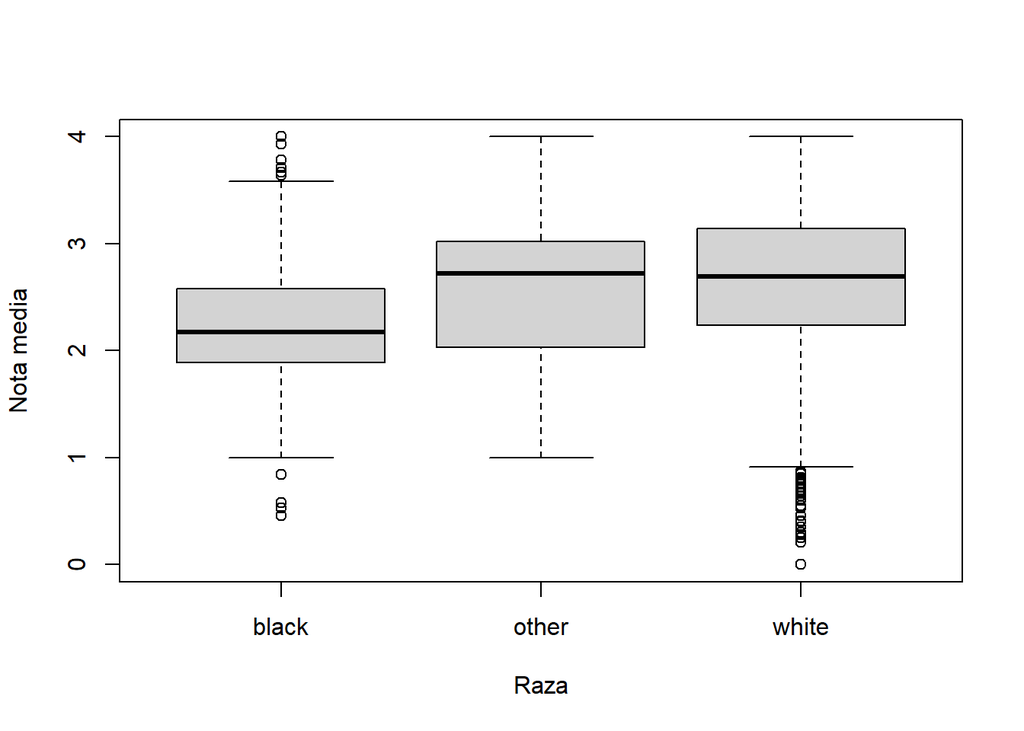

```r
gpaclean$race<-NULL
gpaclean[which(gpaclean$black==TRUE),c("race")]<-"black"
gpaclean[which(gpaclean$white==TRUE),c("race")]<-"white"
gpaclean[which((gpaclean$white==FALSE)&(gpaclean$black==FALSE)),c("race")]<-"other"



gpaclean$race<-as.factor(gpaclean$race)


boxplot(colgpa~race,data=gpaclean,xlab="Raza", ylab="Nota media")
```

## 6.2 Hipótesis nula y alternativa

Nos planteamos si el factor raza es significativo para distribución de colgpa

En la hipótesis nula no lo es y en la hipótesis alternativa existen al menos dos niveles cuyos efectos son significativamente distintos

H0: alfa0=alfa1=alfa2=0

H1: alfai != alfaj para i != j

alfa0 es el efecto del nivel black

alfa1 es el efecto del nivel white

alfa2 es el efecto del nivel other

## 6.3 Modelo

Calculamos la regresión lineal tomando colgpa como variable independiente y la variable creada race como predictora.

“df” lista los grados de libertad para la regresión (numero de valores de race menos 1: k-1) y para los errores (numero de registros de la muestra menos numero de valores de race: N- K)

El f valor será el cociente entre la media de los cuadrados totales y la media de los cuadrados del error.

Las formulas resumidas quedarían así:

race SST df=k−1 MST=SST/(df) F-VALOR=MST/MSE

Error SSE df=N−k MSE=SSE/(df)

como el p-valor es inferior a 0.05 rechazamos la hipótesis nula y concluimos que hay un diferencia estadísticamente significativa

entre las medias de la población . Lo que no sabemos aún si las tres medias son diferentes o cuál de ellas es diferente al resto.

```r
modelo_cg_race<-lm(colgpa~race,data=gpaclean)
taov<-anova(modelo_cg_race)
taov
```

```
## Analysis of Variance Table
##
## Response: colgpa
##             Df  Sum Sq Mean Sq F value    Pr(>F)
## race         2   39.41 19.7061  46.215 < 2.2e-16 ***
## Residuals 4093 1745.26  0.4264
## ---
## Signif. codes:  0 '***' 0.001 '**' 0.01 '*' 0.05 '.' 0.1 ' ' 1
```

## 6.4 Efecto de los niveles de factor

Con la función pairwise.t.test obtenemos los p-valores de todas las comparaciones por parejas.

Se observa un nivel de significancia aceptable para las comparaciones black-white y black-other

```r
pairwise.t.test(gpaclean$colgpa,gpaclean$race, p.adj=c("none"))
```

```
##
##  Pairwise comparisons using t tests with pooled SD
##
## data:  gpaclean$colgpa and gpaclean$race
##
##       black   other
## other 6.1e-06 -
## white < 2e-16 0.55
##
## P value adjustment method: none
```

Otra forma de analizar el efecto de los niveles es hacer comparaciones múltiples con la correción de Bonferroni.

Para cada comparación aparece el p-valor (con asterisco si son considerados significativos) y los intervalos de confianzas correspondientes. Si ponemos el parámetro group a True crea dos grupos:

a: que contiene los niveles para los que no se considera que existen diferencias significativas en sus medias: other y white

b: para black, que es el nivel con media considerada diferente a las otras dos.

Por tanto se obtienen la misma conclusión que con el pairtest.

```r
LSD.test(modelo_cg_race,"race",group=F,p.adj="bonferroni",console=T)
```

```
##
## Study: modelo_cg_race ~ "race"
##
## LSD t Test for colgpa
## P value adjustment method: bonferroni
##
## Mean Square Error:  0.4264006
##
## race,  means and individual ( 95 %) CI
##
##         colgpa       std    r      LCL      UCL  Min Max
## black 2.248444 0.6173364  225 2.163096 2.333793 0.46   4
## other 2.635190 0.6841556   79 2.491154 2.779226 1.00   4
## white 2.679045 0.6543850 3792 2.658256 2.699835 0.00   4
##
## Alpha: 0.05 ; DF Error: 4093
## Critical Value of t: 2.394964
##
## Comparison between treatments means
##
##                difference pvalue signif.        LCL        UCL
## black - other -0.38674543      0     *** -0.5912674 -0.1822235
## black - white -0.43060091      0     *** -0.5379092 -0.3232926
## other - white -0.04385549      1         -0.2216310  0.1339200
```

```r
LSD.test(modelo_cg_race,"race",group=T,p.adj="bonferroni",console=T)
```

```
##
## Study: modelo_cg_race ~ "race"
##
## LSD t Test for colgpa
## P value adjustment method: bonferroni
##
## Mean Square Error:  0.4264006
##
## race,  means and individual ( 95 %) CI
##
##         colgpa       std    r      LCL      UCL  Min Max
## black 2.248444 0.6173364  225 2.163096 2.333793 0.46   4
## other 2.635190 0.6841556   79 2.491154 2.779226 1.00   4
## white 2.679045 0.6543850 3792 2.658256 2.699835 0.00   4
##
## Alpha: 0.05 ; DF Error: 4093
## Critical Value of t: 2.394964
##
## Groups according to probability of means differences and alpha level( 0.05 )
##
## Treatments with the same letter are not significantly different.
##
##         colgpa groups
## white 2.679045      a
## other 2.635190      a
## black 2.248444      b
```

## 6.5 Conclusiones

Tras los distintos test hechos llegamos a la conclusión con respecto a la variabilidad de colgpa en función de race de que

únicamente el efecto del nivel “black” tiene significancia estadística. Es algo que ya se intuía al analizar el diagrama de cajas,

donde la media para race=black se encontraba más alejada de las otras dos.

## 6.6 Normalidad de los residuos

Para evaluar la normalidad de los residuos usaremos el test de Shapiro-Wilk, cuya hipótesis nula afirma que la distribución es normal.

Al obtener un p-valor cercano a cero hay que rechazarla y no podemos asumir que los residuos siguen una distribución normal.

Este resultado es coherente con la gráfica cuantil-cuantil, donde también vemos que los valores residuales no se distribuyen completamente alienados a lo largo de toda la recta de 45 grados fuera del rango intercuantil.

```r
results <- resid(modelo_cg_race)
shapiro.test(results)
```

```
##
##  Shapiro-Wilk normality test
##
## data:  results
## W = 0.99175, p-value = 1.121e-14
```

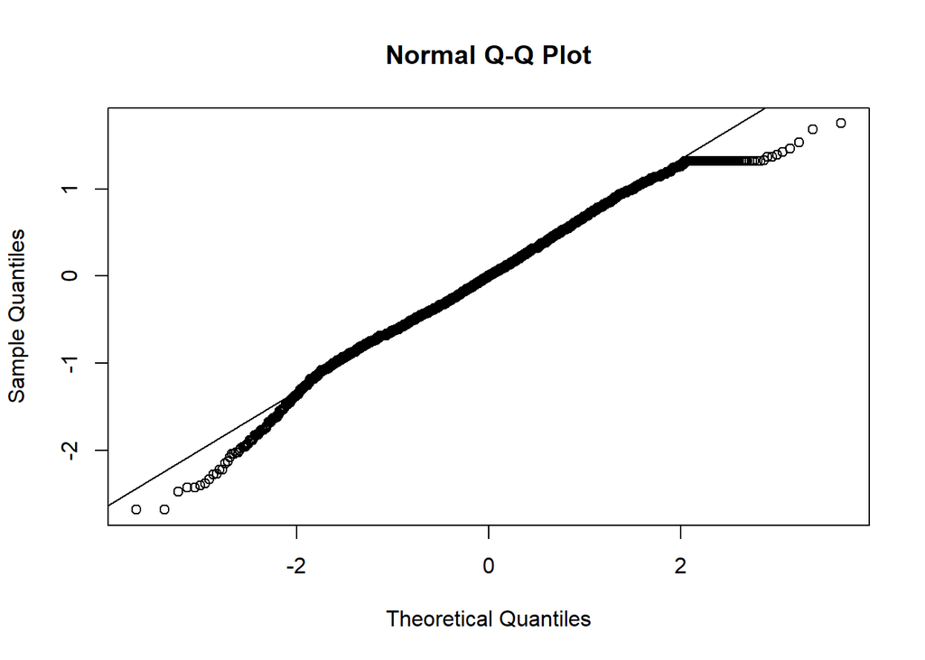

```r
qqnorm(results)
qqline(results)
```

## 6.7 Homocedasticidad de los residuos

Vemos tres lineas verticales de puntos que están situadas en las medias de cada grupo que corresponden a los valores ajustados de las observaciones.

Podemos apreciar una dispersión parecida en cada tira, con lo cual asumimos que la varianza del error es constante para los tres niveles.

```r
sum(gpaclean$race=="white")
```

```
## [1] 3792
```

```r
sum(gpaclean$race=="black")
```

```
## [1] 225
```

```r
sum(gpaclean$race=="other")
```

```
## [1] 79
```

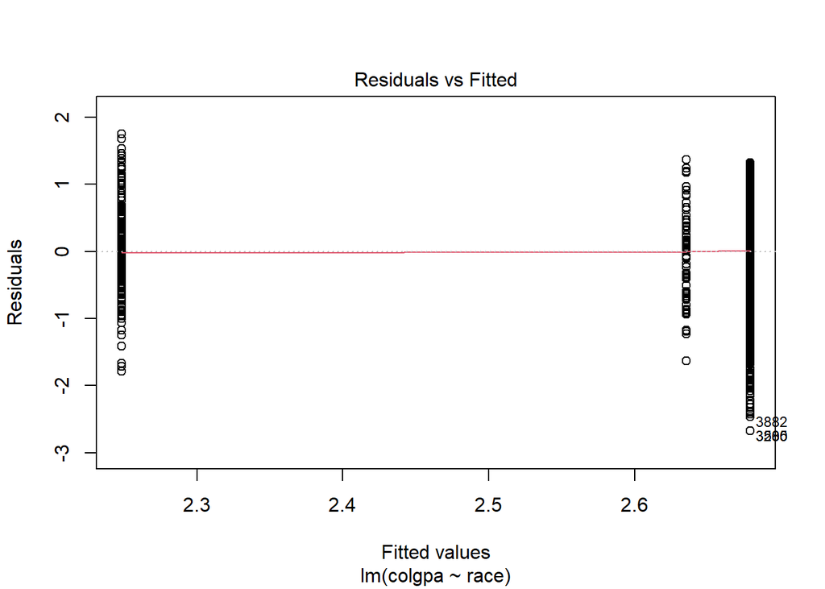

```r
plot(modelo_cg_race, 1)
```

# 7 ANOVA multifactorial

## 7.1 Análisis visual de los efectos principales y posibles interacciones

A través de esta gráfica vemos que para los valores de race, black y white la variable female tiene una relación positiva frente a colgpa.

No ocurre así para race igual a other, donde ser mujer da lugar a una media de gcolgpa más baja.

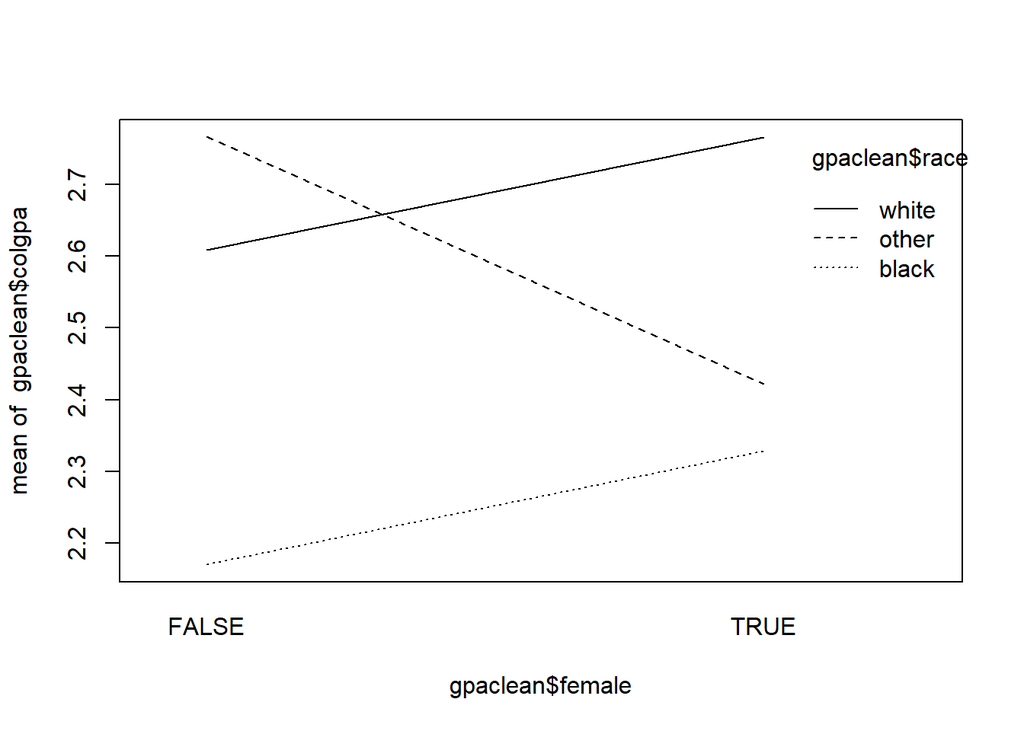

```r
interaction.plot(gpaclean$female,gpaclean$race,gpaclean$colgpa)
```

## 7.2 Cálculo del modelo

Hacemos uso de la función aov, que invocara a la funcion lm una vez por factor.

```r
modelo_aov<- aov(colgpa ~ race*female, data = gpaclean)
```

## 7.3 Interpretación de los resultados

Usamos la función anova para obtener la tabla de análisis de la varianza cuyas columnas ya explicamos en el apartado anterior.

El F-valor para la interacción entre las dos factores también es significativo, luego concluimos que no solo ambos factores tienen efecto en colgpa sino que además existe una interacción entre los distintos niveles de los factores.

Para entrar en el detalle de esas interacciones habrá que practircar análisis a posteriori.

```r
anova(modelo_aov)
```

```
## Analysis of Variance Table
##
## Response: colgpa
##               Df  Sum Sq Mean Sq F value    Pr(>F)
## race           2   39.41 19.7061 46.8976 < 2.2e-16 ***
## female         1   22.06 22.0627 52.5058 5.102e-13 ***
## race:female    2    4.60  2.2978  5.4685  0.004249 **
## Residuals   4090 1718.60  0.4202
## ---
## Signif. codes:  0 '***' 0.001 '**' 0.01 '*' 0.05 '.' 0.1 ' ' 1
```

## 7.4 Adecuación del modelo

De nuevo el test de Shapiro y la gráfica cuantil-cuantil nos sugieren que los residuos no siguen una distribución normal.

```r
results <- resid(modelo_aov)
shapiro.test(results)
```

```
##
##  Shapiro-Wilk normality test
##
## data:  results
## W = 0.99267, p-value = 1.172e-13
```

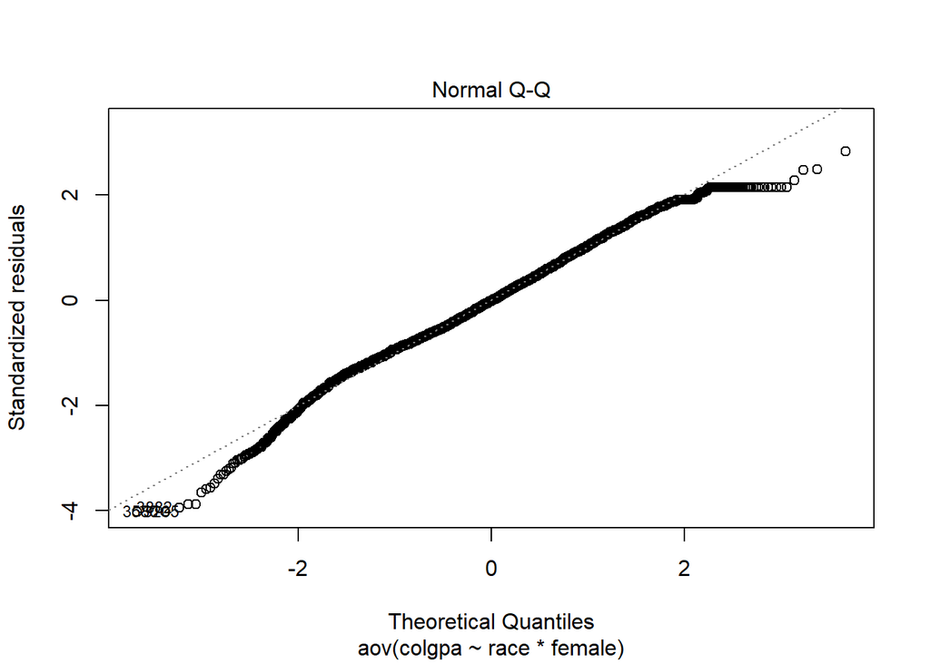

```r
plot(modelo_aov, which = 2)
```

En esta ocasión la varianza de los residuos también es constante.

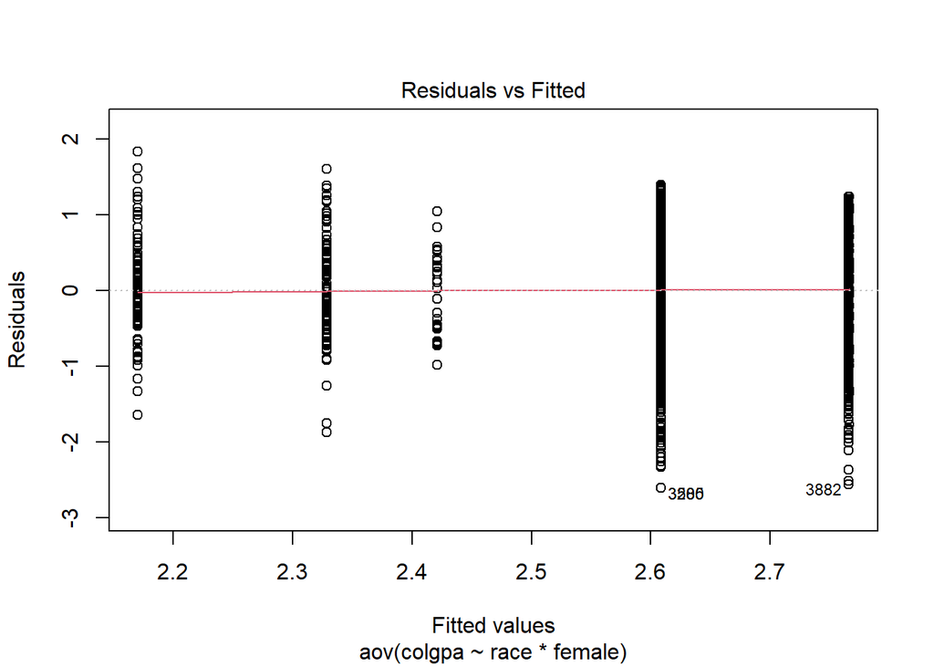

```r
plot(modelo_aov, which = 1)
```

# 8 Conclusiones

Tras haber leido y preparado los datos se ha hecho un análisis descriptivo de las distintas variables donde ya se anticipa lo que hemos confirmado en secciones posteriores: la correlación entre female, colgpaletter y sat.

En el tercer apartado hemos hecho un estudio inferencial para las variables sat y colgpa.

Con respecto a la primera hemos visto que para un intervalo de confianza del 95% no existe solapamiento entre los intervalos de la media para los subgrupos de estudiantes hombres y estudiantes mujeres.

Para colgpa hemos hecho un contraste de hipótesis sobre si la media poblacional para las estudiantes mujeres es distinta que la de los estudiantes hombres llegando a la conclusión que para un nivel de confianza del 95% hay que rechazar la hipótesis nula.

En el cuarto apartado el modelo de regresión lineal generado para colgpa ha obtenido un coeficiente de determinación muy bajo si bien todas las variables dependientes tienen un nivel de significancia próximo a cero y por tanto aportan al modelo. Tal vez la regresión lineal no es el mejor modelo o habría que seguir añadiendo más predictores y comprobar si mejoran la bondad del ajuste.

En el modelo de regresión logística del quinto apartado la bondad del ajuste es aceptable pues la devianza residual es inferior a la nula.

También hemos llegado a la conclusión que las variables white y athlete no aportan mejoras al modelo, es decir, no existe una correlación significante con con los valores de colgpa considerados como excelentes.

En el caso de la variable female sí que existe una correlación ya que se ha obtenido un OR de 1.53.

En el apartado 6 hemos hecho un análisis de la varianza de colgpa en función de los niveles race como factor.

Primero se ha calculado la tabla ANOVA del modelo de regresión lineal correspondiente y se ha rechazado la hipótesis nula

de que los efectos de cada nivel del race sean iguales .

Posteriormente gracias al pairwise test y a la corrección de Bonferroni se ha concluido que la media del nivel black es significativamente

distinta a la del resto de niveles.

Se ha observado que no se puede confirmar que los residuos se distribuyen de forma normal aunque si hay una varianza del error que es constante para todos los niveles del factor.

Por útlimo se ha hecho una anova multifactorial añadiendo la variable female en la que se ha comprobado que ambos factores tienen efecto y además entre ellos existe una interacción significativa. En este apartado también se ha rechazado la hipótesis de que los residuos siguen una distribución normal y además se aprecia gráficamente homocedasticidad.